# Project 3 Technical Report

Bea Sauve, Elton nichols, Kainen Osborne

2026-03-03

# Timeless Transport Models Resource Analysis and Profit Forecasting

## *Business Objective*

Timeless Transport Models is a Business to Business company focusing on the production and distribution of modeled vehicles. Since 2003 they have been accumulating data regarding customer engagement, sales and productions, and distribution.Timeless Transport Models operates three factories producing two product lines each. As the company enters the second half of 2005 (June-December), leadership requires production forecasts, cost analysis, and projected profit estimates.  
This report will entail:

- Aggregates of weekly production and cost data into monthly totals
- Exploratory data analysis
- Forecasts of monthly production (June–December 2005)
- Calculations of average cost and profit per product line
- Projects total expected profit for the remainder of 2005

All analyses are conducted in R using reproducible workflows. Specifications regarding specific team member contributions will be included in the R chunk title or described directly in this document. Explicit information regarding team member contributions are listed in the CONTRIBUTING.md file located in the git repository.

## *Expected Uses*

This analysis is intended to support strategic and operational decisions for Timeless Transport Models during the second half of 2005. Specifically, the results of this forecasting and profit analysis may be used in the following ways:

- Production Planning
- Budgeting and financial Planning
- Product line Strategies
- Factory Performance Evaluations
- Scenario Planning
- Strategical Decision Making

## *Data Refinement*

To kick off this project we must ensure that our data is properly set up for analysis. Data preparations includes importing and formatting data sets, correcting any missing or inaccurate values, and aggregating the data. The data refinement portion of this project was conducted by Bea, our Project Manager.

#### Library Packages to Install

To begin refinement we must first import the data sets and any libraries needed for this analysis.

- If you plan on running this Project Notebook, and do not have these packages installed navigate to the R Studio Console and copy/paste the install package you do not yet have.

```r
install.packages("readr")      # Read and import data
install.packages("tidyverse")  # Data manipulation and visualization
install.packages("lubridate")  # Date handling and weekday conversion
install.packages("forecast")   # Time series forecasting
install.packages("ggplot2")    # Data visualization
install.packages("dplyr")      # Data transformation
install.packages("car")        # Companion to Applied Regression
install.packages("MASS")       # Statistical functions
install.packages("DT")         # Renders Data Tables
```

#### Library Packages to Load

```r
library(readr)
library(tidyverse)
```

```r
library(lubridate)
library(forecast)
library(ggplot2)
library(dplyr)
library(car)
library(MASS)
library(DT)
```

#### Import Data Files

With the libraries fully loaded, we must now import the data sets we will be using to conduct our analysis. The file used to conduct said analysis is the “weekly_factory_production.csv”. This file contains information regarding our production numbers, production costs, the locations and dates of where said items were produced. Additionally, the file will be referred to as “production_data” for the remainder of this analysis. “sales_data_cleaned.csv” is a file containing our customer order data, sales and distributions from 2003-2005. This file will be used for profit analysis, and will be referred to as “sales_data”.

```r
# Import production data, convert weeks into date datatype
production_data <- read_csv('CSV/weekly_factory_production.csv',
                            col_types = cols(
                              week = col_date(format = "%Y-%m-%d")))

# Import sales data, Convert N/A values back to North America, and convert date into date datatype
sales_data <- read_csv("CSV/sales_data_sample_cleaned.csv")
sales_data$TERRITORY[is.na(sales_data$TERRITORY)] <- "NA"
sales_data$ORDERDATE <- mdy(sales_data$ORDERDATE)
```

#### Data Transformation

With the data fully imported, we now need to refine the data to sure its accuracy for the conduction of analyses.

Data refinement may include, but is not subject to:

- Modifications of missing or Null values
- Altering of data types
- Renaming variables
- Mathematical implementations
- Data Standardization
- Management of outliers
- Normalizing Data
- Aggregating Data

Modifications conducted on this data set include, altering data types, mathematical implementations,and data aggregation. We start the process by inspecting our data first, then refine based on our findings.

```
## [1] "Inspect Data Types"
```

```
## spc_tbl_ [375 × 10] (S3: spec_tbl_df/tbl_df/tbl/data.frame)
##  $ week            : Date[1:375], format: "2003-01-12" "2003-01-12" ...
##  $ factory_id      : num [1:375] 0 1 2 0 1 2 0 1 2 0 ...
##  $ weekly_cost     : num [1:375] 1236 2851 1642 2112 932 ...
##  $ Classic Cars    : num [1:375] 5 0 0 1 0 0 5 0 0 0 ...
##  $ Motorcycles     : num [1:375] 0 29 0 0 11 0 0 17 0 0 ...
##  $ Planes          : num [1:375] 0 0 0 0 0 1 0 0 24 0 ...
##  $ Ships           : num [1:375] 25 0 0 89 0 0 9 0 0 17 ...
##  $ Trucks and Buses: num [1:375] 0 5 0 0 0 0 0 7 0 0 ...
##  $ Vintage Cars    : num [1:375] 0 0 21 0 0 24 0 0 0 0 ...
##  $ outlier         : num [1:375] 0 0 0 0 0 0 0 0 0 0 ...
##  - attr(*, "spec")=
##   .. cols(
##   ..   week = col_date(format = "%Y-%m-%d"),
##   ..   factory_id = col_double(),
##   ..   weekly_cost = col_double(),
##   ..   `Classic Cars` = col_double(),
##   ..   Motorcycles = col_double(),
##   ..   Planes = col_double(),
##   ..   Ships = col_double(),
##   ..   `Trucks and Buses` = col_double(),
##   ..   `Vintage Cars` = col_double(),
##   ..   outlier = col_double()
##   .. )
##  - attr(*, "problems")=<externalptr>
```

```
## [1] "Summarize Data Statistics"
```

```
##       week              factory_id  weekly_cost      Classic Cars
##  Min.   :2003-01-12   Min.   :0    Min.   : 376.9   Min.   : 0.000
##  1st Qu.:2003-08-17   1st Qu.:0    1st Qu.:1152.4   1st Qu.: 0.000
##  Median :2004-03-21   Median :1    Median :1661.7   Median : 0.000
##  Mean   :2004-03-21   Mean   :1    Mean   :1843.3   Mean   : 1.019
##  3rd Qu.:2004-10-24   3rd Qu.:2    3rd Qu.:2413.3   3rd Qu.: 1.000
##  Max.   :2005-05-29   Max.   :2    Max.   :5975.7   Max.   :13.000
##   Motorcycles         Planes           Ships        Trucks and Buses
##  Min.   : 0.000   Min.   : 0.000   Min.   :  0.00   Min.   : 0.000
##  1st Qu.: 0.000   1st Qu.: 0.000   1st Qu.:  0.00   1st Qu.: 0.000
##  Median : 0.000   Median : 0.000   Median :  0.00   Median : 0.000
##  Mean   : 3.139   Mean   : 3.984   Mean   : 10.13   Mean   : 2.539
##  3rd Qu.: 2.000   3rd Qu.: 3.000   3rd Qu.: 10.50   3rd Qu.: 3.000
##  Max.   :30.000   Max.   :39.000   Max.   :101.00   Max.   :27.000
##   Vintage Cars       outlier
##  Min.   : 0.000   Min.   :   0.00
##  1st Qu.: 0.000   1st Qu.:   0.00
##  Median : 0.000   Median :   0.00
##  Mean   : 4.568   Mean   :  54.74
##  3rd Qu.: 4.000   3rd Qu.:   0.00
##  Max.   :43.000   Max.   :1163.17
```

```
## [1] "Verify Missing Values"
```

```
##             week       factory_id      weekly_cost     Classic Cars
##                0                0                0                0
##      Motorcycles           Planes            Ships Trucks and Buses
##                0                0                0                0
##     Vintage Cars          outlier
##                0                0
```

It appears as though there are no major discrepancies to address within our data. Next we will refine our data to include metrics, summaries metrics, and aggregate data into a monthly format or a product line format. We first begin this process by creating basic columns such as a year and month column, calculating total units, and calculating an aggregate cost per unit.

```r
# Implement a Month column displaying the month and year for aggregation and visualization
production_data$Month <- format(production_data$week, "%Y-%m")
# Create a Month_Ordered Column containing the month and year combined. Will be used for future aggregations
sales_data$MONTH_ORDERED <- format(sales_data$ORDERDATE, "%Y-%m")

# Rename all columns to exclude spaces
production_data <- production_data %>%
  rename(
     "Classic_Cars" = `Classic Cars`,
     "Trucks_and_Buses" = `Trucks and Buses`,
     "Vintage_Cars" = `Vintage Cars`
  )

sales_data <- sales_data %>%
  mutate(PRODUCTLINE = gsub(" ", "_", PRODUCTLINE))


# Calculate total production
production_data$TOTAL_UNITS <- production_data$Classic_Cars + production_data$Motorcycles + production_data$Planes +
  production_data$Ships + production_data$Trucks_and_Buses + production_data$Vintage_Cars

# We need to know the rough cost to produce individual products. Calculate the Cost Per Unit (CPU) by dividing the total sales by the total units.
production_data$`AGGREGATE_CPU` <- production_data$weekly_cost / production_data$TOTAL_UNITS

# The outlier column indicates sections of weekly cost data that deviates from the norm. Create a flag column with 1 indicating that the row has outlieing data
production_data$outlier_flag <- if_else(production_data$outlier > 0, 1, 0)

# Define colors palette for visualizations
palette <- c(
    "Classic_Cars"     = "darkred",
    "Motorcycles"      = "goldenrod",
    "Planes"           = "bisque1",
    "Ships"            = "darkolivegreen",
    "Trucks_and_Buses" = "gray51",
    "Trains"           = "darkorange4",
    "Vintage_Cars"     = "dodgerblue4"
  )
```

### Aggregation by Productline

Some important features for our analysis include the analyzing of our profits and production based on product lines. We need to aggregate our production data by months and product line types to get a full visualization of our costs and profits based on the specific products we are producing. We will also include a column of the factory the product was produced in for further analysis of our individual factories.

For clarity regarding our individual products, we must convert our data into a long format, placing each product within a Productline column as opposed to our current format with columns labeled by each product we produce. We would also like to include an aggregation of the production costs for each of these units by multiplying our aggregated cost per unit by the total number of units produced.

```
## # A tibble: 2,250 × 11
## # Groups:   Month [29]
##    week       factory_id weekly_cost outlier Month   TOTAL_UNITS AGGREGATE_CPU
##    <date>          <dbl>       <dbl>   <dbl> <chr>         <dbl>         <dbl>
##  1 2003-01-12          0       1236.       0 2003-01          30          41.2
##  2 2003-01-12          0       1236.       0 2003-01          30          41.2
##  3 2003-01-12          0       1236.       0 2003-01          30          41.2
##  4 2003-01-12          0       1236.       0 2003-01          30          41.2
##  5 2003-01-12          0       1236.       0 2003-01          30          41.2
##  6 2003-01-12          0       1236.       0 2003-01          30          41.2
##  7 2003-01-12          1       2851.       0 2003-01          34          83.8
##  8 2003-01-12          1       2851.       0 2003-01          34          83.8
##  9 2003-01-12          1       2851.       0 2003-01          34          83.8
## 10 2003-01-12          1       2851.       0 2003-01          34          83.8
## # ℹ 2,240 more rows
## # ℹ 4 more variables: outlier_flag <dbl>, PRODUCTLINE <chr>,
## #   UNITS_PRODUCED <dbl>, AGG_PRODUCT_COSTS <dbl>
```

#### Productline Regression Modeling

Some issues that arise with the implementation of aggregated costs per unit and calculated productions based on the CPU calculations are the inaccuracies of the calculated metrics. This form of calculation leads to over generalization of the data, and can include compounded floating point errors over time. The best and most accurate solution to calculate accurate CPU’s per product line is by conducting a multiple regression analysis on our product line costs.

Listed below is the final conduction of the multiple regression analysis. The analysis began by only running the regression model on the productline, but this resulted in a model with only 77% accuracy. An additional analysis was conducted my separating the data by factory types and conducting an analysis of the product lines based on each factory. However, this led to less accurate regression results with 61%-68% accuracy rates. We also note that there resides an “outlier” column within our data set. This column lets us know how far the weekly costs have deviated from our standard weekly costs. To account for the outliers, we will use a flag column to indicate where the outlier data resides. The outlying data will then be used as weights in our linear model to account for items that may be skewing the data. A Linear model will be used in our calculations with outliers as weights to downwight any extreme observations, giving us more stable cost estimates.

```
##
## Call:
## lm(formula = weekly_cost ~ Classic_Cars + Motorcycles + Planes +
##     Ships + Trucks_and_Buses + Vintage_Cars + factor(factory_id),
##     data = production_data, weights = if_else(production_data$outlier ==
##         0, 1, 0))
##
## Weighted Residuals:
##     Min      1Q  Median      3Q     Max
## -348.15  -41.26  -15.92    2.64 1175.95
##
## Coefficients:
##                      Estimate Std. Error t value Pr(>|t|)
## (Intercept)          448.0299    51.6094   8.681  < 2e-16 ***
## Classic_Cars          83.7260     7.5943  11.025  < 2e-16 ***
## Motorcycles           75.0901     2.7103  27.705  < 2e-16 ***
## Planes                83.1043     2.4531  33.878  < 2e-16 ***
## Ships                 15.9091     0.9927  16.026  < 2e-16 ***
## Trucks_and_Buses      91.0393     3.7090  24.546  < 2e-16 ***
## Vintage_Cars          66.6728     2.2039  30.252  < 2e-16 ***
## factor(factory_id)1 -191.3427    73.2079  -2.614  0.00935 **
## factor(factory_id)2   98.7422    76.0701   1.298  0.19514
## ---
## Signif. codes:  0 '***' 0.001 '**' 0.01 '*' 0.05 '.' 0.1 ' ' 1
##
## Residual standard error: 226.4 on 346 degrees of freedom
## Multiple R-squared:  0.9282, Adjusted R-squared:  0.9266
## F-statistic: 559.5 on 8 and 346 DF,  p-value: < 2.2e-16
```

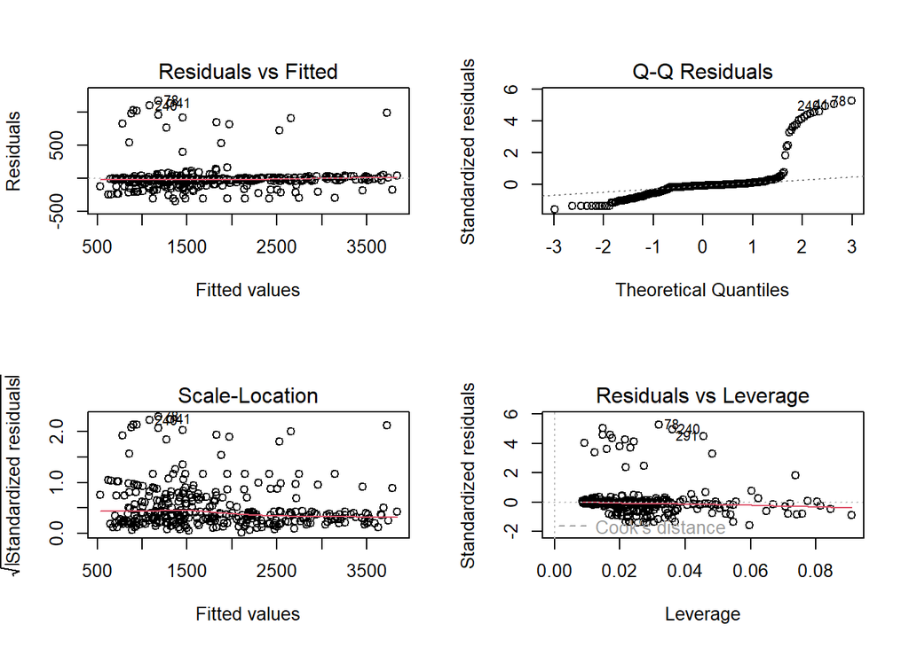

The final determination was to run the multiple regression analysis with all of the products, the factory id’s, and our outlier data. The resulting regression model lead to a 92% accuracy rating. Our residuals model shows clusters of dots near the 0 line. Showing that the majority of our estimated data has a close fit accuracy. There are large outliers in the data but our model accounted for that. The Q-Q residuals show that a majority of our predicted costs are predicted perfectly with a pattern. However, we have a heavy tail resulted from our outlier data. The Scale-Location presents a relatively flat line with relatively consistent distribution of data. This means that our predicted costs have been balanced successfully. The residuals vs leverage chart displays a few points that deviate far from the red line, but our data doesn’t exceed Cook’s distance. Therefore, we dont have data points that break the accuracy of our cost estimates, and its safe to use the calculated regression data.

#### Implement Regression Modeling

With our CPU’s estimated, we will now incorporate them into our product line data set. The aggregated average CPU’s will remain inside the data set for comparison of mathematical discrepancies. We will incorporate the regression information by mutating the regression CPU’s into our elongated data set, excluding product lines that did not produce anything. We will also include calculations of our factory base costs my mutating in the regression base intercepts by our factory ID’s.

```
## # A tibble: 2,250 × 14
## # Groups:   Month [29]
##    week       factory_id weekly_cost outlier Month   TOTAL_UNITS AGGREGATE_CPU
##    <date>          <dbl>       <dbl>   <dbl> <chr>         <dbl>         <dbl>
##  1 2003-01-12          0       1236.       0 2003-01          30          41.2
##  2 2003-01-12          0       1236.       0 2003-01          30          41.2
##  3 2003-01-12          0       1236.       0 2003-01          30          41.2
##  4 2003-01-12          0       1236.       0 2003-01          30          41.2
##  5 2003-01-12          0       1236.       0 2003-01          30          41.2
##  6 2003-01-12          0       1236.       0 2003-01          30          41.2
##  7 2003-01-12          1       2851.       0 2003-01          34          83.8
##  8 2003-01-12          1       2851.       0 2003-01          34          83.8
##  9 2003-01-12          1       2851.       0 2003-01          34          83.8
## 10 2003-01-12          1       2851.       0 2003-01          34          83.8
## # ℹ 2,240 more rows
## # ℹ 7 more variables: outlier_flag <dbl>, PRODUCTLINE <chr>,
## #   UNITS_PRODUCED <dbl>, AGG_PRODUCT_COSTS <dbl>, REGRESSION_CPU <dbl>,
## #   REG_FACTORY_BASE_COST <dbl>, REG_TTL_PROD_COST_NO_BASE <dbl>
```

#### Convert Weekly to Monthly

With the accurate regression metrics now implemented, we need to aggregate the weekly data into monthly data. We will create a new data set using the former data set we just created. This data set will aggregate the information of the former data set by month, product line, and factory ID. We will also re implement the regression statistics to avoid compounding calculations that may affect accurate data metrics. This data set will not include products that had zero production. Based on previous data set observations we can note that which factories are exclusive to the products they produce. Lastly, we will implement production metrics based on the implemented regression metrics to give us an idea of the costs to produce each product.

```
## # A tibble: 174 × 8
##    Month   PRODUCTLINE      factory_id TOTAL_UNITS_PRODUCED REGRESSION_CPU
##    <chr>   <chr>                 <dbl>                <dbl>          <dbl>
##  1 2003-01 Classic_Cars              0                   11           83.7
##  2 2003-01 Motorcycles               1                   57           75.1
##  3 2003-01 Planes                    2                   25           83.1
##  4 2003-01 Ships                     0                  123           15.9
##  5 2003-01 Trucks_and_Buses          1                   12           91.0
##  6 2003-01 Vintage_Cars              2                   45           66.7
##  7 2003-02 Classic_Cars              0                   10           83.7
##  8 2003-02 Motorcycles               1                   15           75.1
##  9 2003-02 Planes                    2                   62           83.1
## 10 2003-02 Ships                     0                   53           15.9
## # ℹ 164 more rows
## # ℹ 3 more variables: REG_FACTORY_BASE_COST <dbl>, REG_PROD_COST_NO_BASE <dbl>,
## #   AVG_PRODUCTION_COST_W_BASE <dbl>
```

#### Conjoin Sales and Monthly Production by Productline

We are now in the last steps of building out sales and production data set by product line. To incorporate our sales into this data set we must summarize our sales data by product line and date sold. With the sales data condensed in this format we may conduct a full join between the two data sets. Our aggregated sales data by product line will include min, avg, and max price sold columns due to the variance in which our products were sold by distributors. These segregated values will allow us to determine optimal prices to sell our products for. Below is our aggregated sales data.

[output not shown]

```
## # A tibble: 180 × 8
## # Groups:   MONTH_ORDERED [29]
##    MONTH_ORDERED PRODUCTLINE      MIN_PRICE_SOLD AVG_PRICE_SOLD MAX_PRICE_SOLD
##    <chr>         <chr>                     <dbl>          <dbl>          <dbl>
##  1 2003-01       Classic_Cars               39.6           89.5          100
##  2 2003-01       Trains                     53.3           59.6           65.9
##  3 2003-01       Trucks_and_Buses           47.6           88.8          100
##  4 2003-01       Vintage_Cars               31.2           75.7          100
##  5 2003-02       Classic_Cars              100            100            100
##  6 2003-02       Motorcycles                70.9           92.8          100
##  7 2003-02       Planes                     52.6           80.9          100
##  8 2003-02       Ships                      56.8           80.9          100
##  9 2003-02       Trains                    100            100            100
## 10 2003-02       Vintage_Cars               40.2           75.1          100
## # ℹ 170 more rows
## # ℹ 3 more variables: AVG_SHIPPED_PER_ORDER <dbl>, TOTAL_SHIPPED <dbl>,
## #   TOTAL_SALES <dbl>
```

Lastly, we will combine the sales data with our factory data. With these two conjoined, we will implement revenue and profit metrics. Our Revenue metrics will range from min, avg, and max revenue based on the summary metrics we gathered regarding our sale prices. This data will give us an idea of our revenue ranges. The same will be done with our profit margins. However, we will implement our actual profit margins based on our total sales and production costs.

```
## # A tibble: 197 × 24
##    Month   PRODUCTLINE      factory_id TOTAL_UNITS_PRODUCED REGRESSION_CPU
##    <chr>   <chr>            <fct>                     <dbl>          <dbl>
##  1 2003-01 Classic_Cars     0                            11           83.7
##  2 2003-01 Motorcycles      1                            57           75.1
##  3 2003-01 Planes           2                            25           83.1
##  4 2003-01 Ships            0                           123           15.9
##  5 2003-01 Trucks_and_Buses 1                            12           91.0
##  6 2003-01 Vintage_Cars     2                            45           66.7
##  7 2003-02 Classic_Cars     0                            10           83.7
##  8 2003-02 Motorcycles      1                            15           75.1
##  9 2003-02 Planes           2                            62           83.1
## 10 2003-02 Ships            0                            53           15.9
## # ℹ 187 more rows
## # ℹ 19 more variables: REG_FACTORY_BASE_COST <dbl>,
## #   REG_PROD_COST_NO_BASE <dbl>, AVG_PRODUCTION_COST_W_BASE <dbl>,
## #   MIN_PRICE_SOLD <dbl>, AVG_PRICE_SOLD <dbl>, MAX_PRICE_SOLD <dbl>,
## #   AVG_SHIPPED_PER_ORDER <dbl>, TOTAL_SHIPPED <dbl>, TOTAL_SALES <dbl>,
## #   MIN_PRODUCT_PROFIT <dbl>, AVG_PRODUCT_PROFIT <dbl>,
## #   MAX_PRODUCT_PROFIT <dbl>, MIN_TOTAL_REVENUE <dbl>, …
```

This data is now ready for analysis conducting on our product line and further regression modeling.

### Aggregated Monthly Data by Month

While it is insightful looking at the minute details of our product line. We would also like general information regarding our monthly sales and production without the noise of our product line. We will create an additional data set to conduct analyses on. Used for overview analyses and regression modeling. The overview of the data set construction includes summarizing our productions by month only and implementing regression metrics, summarizing our sales by month only, and conjoining the to with the implementation of revenue and profit metrics.

We first begin this process by grouping our original production data by months. We will also implement summary metric such as total production costs, and total units produced. The grouped data set will also implement our regression metrics indicated by our regression models predicted costs, and calculations of our average CPU’s by dividing our predicted monthly costs by our actual production. We will also include the variance between actual and predicted for further comparisons.

```
## # A tibble: 29 × 7
##    Month MONTHLY_PRODUCTION ACTUAL_MONTHLY_COST PRED_MONTHLY_COST ACTUAL_AVG_CPU
##    <chr>              <dbl>               <dbl>             <dbl>          <dbl>
##  1 2003…                273              16381.            17083.           60.0
##  2 2003…                242              22112.            21228.           91.4
##  3 2003…                321              27134.            24533.           84.5
##  4 2003…                306              25890.            22440.           84.6
##  5 2003…                293              24193.            22478.           82.6
##  6 2003…                318              26670.            24331.           83.9
##  7 2003…                241              23390.            20639.           97.1
##  8 2003…                456              29889.            30969.           65.5
##  9 2003…                228              18842.            18252.           82.6
## 10 2003…                313              24358.            21557.           77.8
## # ℹ 19 more rows
## # ℹ 2 more variables: REGRESSION_AVG_CPU <dbl>, CPU_VARIANCE <dbl>
```

For our sales implementation, we will create another monthly sales data set. Only grouping the sales data by month as opposed to month and product line. Similarly to the former sales set, we will also include the ranged metrics of our selling prices.

```
## # A tibble: 29 × 7
##    MONTH_ORDERED MIN_PRICE_SOLD AVG_PRICE_SOLD MAX_PRICE_SOLD
##    <chr>                  <dbl>          <dbl>          <dbl>
##  1 2003-01                 31.2           82.1            100
##  2 2003-02                 40.2           83.9            100
##  3 2003-03                 32.1           81.7            100
##  4 2003-04                 30.1           84.9            100
##  5 2003-05                 31.0           82.0            100
##  6 2003-06                 38.2           84.3            100
##  7 2003-07                 35.9           86.2            100
##  8 2003-08                 35.8           83.2            100
##  9 2003-09                 33.2           84.3            100
## 10 2003-10                 27.2           84.6            100
## # ℹ 19 more rows
## # ℹ 3 more variables: AVG_SHIPPED_PER_ORDER <dbl>, TOTAL_SHIPPED <dbl>,
## #   TOTAL_SALES <dbl>
```

Lastly, we will combine the two data sets. This combination will be implemented by a full join of both sets. Post join, Revenue ranges will be calculated, and so too will profit ranges. The Profit ranges will also include the Actual profit of our company. Actual profit is calculated by taking our actual sales and subtracting them by our actual monthly costs.

```
## # A tibble: 29 × 23
##    Month MONTHLY_PRODUCTION ACTUAL_MONTHLY_COST PRED_MONTHLY_COST ACTUAL_AVG_CPU
##    <chr>              <dbl>               <dbl>             <dbl>          <dbl>
##  1 2003…                273              16381.            17083.           60.0
##  2 2003…                242              22112.            21228.           91.4
##  3 2003…                321              27134.            24533.           84.5
##  4 2003…                306              25890.            22440.           84.6
##  5 2003…                293              24193.            22478.           82.6
##  6 2003…                318              26670.            24331.           83.9
##  7 2003…                241              23390.            20639.           97.1
##  8 2003…                456              29889.            30969.           65.5
##  9 2003…                228              18842.            18252.           82.6
## 10 2003…                313              24358.            21557.           77.8
## # ℹ 19 more rows
## # ℹ 18 more variables: REGRESSION_AVG_CPU <dbl>, CPU_VARIANCE <dbl>,
## #   MIN_PRICE_SOLD <dbl>, AVG_PRICE_SOLD <dbl>, MAX_PRICE_SOLD <dbl>,
## #   AVG_SHIPPED_PER_ORDER <dbl>, TOTAL_SHIPPED <dbl>, TOTAL_SALES <dbl>,
## #   MIN_PRODUCT_PROFIT <dbl>, AVG_PRODUCT_PROFIT <dbl>,
## #   MAX_PRODUCT_PROFIT <dbl>, MIN_TOTAL_REVENUE <dbl>, AVG_TOTAL_REVENUE <dbl>,
## #   MAX_TOTAL_REVENUE <dbl>, MIN_TOTAL_PROFIT <dbl>, AVG_TOTAL_PROFIT <dbl>, …
```

#### Any Additional Modifications

Both data sets have been constructed. We may now move into the analysis phase. This phase will include EDA of our profits and productions as well as forecasting using regression modeling and verification.

#### Data Assumptions

Several Assumptions are made for this data cleaning process…

- Production values belong to the month of the recorded date,
- Missing values represent incomplete reporting rather than zero production.
- Production and cost values are indicative values of the week they were produced and not a compounding of former weeks
- The data represents continuous weekly reporting without major time gaps.
- All data presented is the only data available to us.

## *Exploratory Data Analysis*

Now that we have our monthly production data, we can search for patterns in that data. First we will visualize the total production to see if there are any overarching patterns before we dig any deeper.

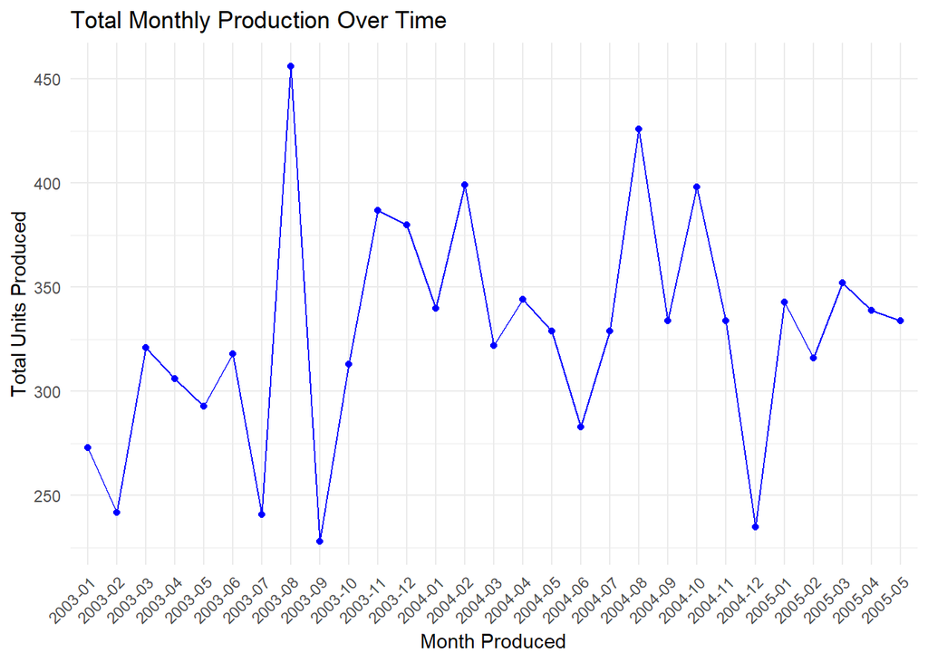

There doesn’t seem to be much of a pattern there, so let’s look at the production by product line.

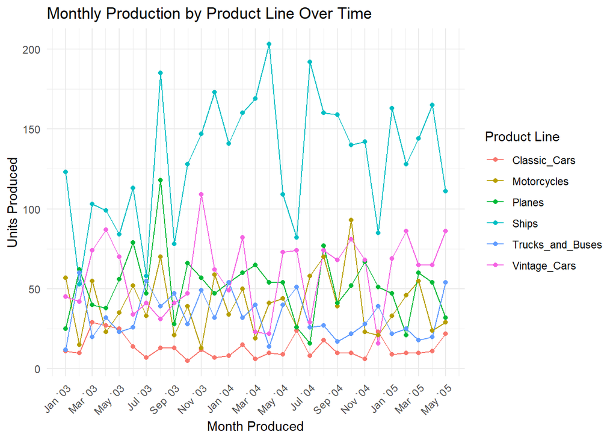

It’s still a bit jumbled, so now we will separate the data by factory.

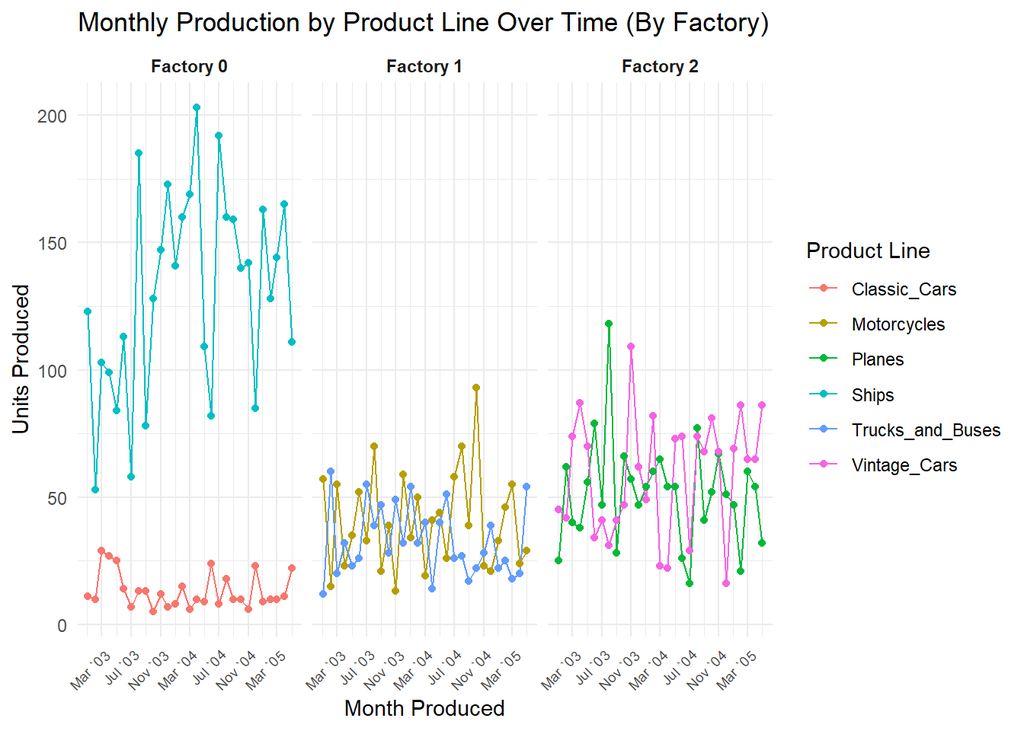

Now we can clearly see that Ships have much higher production levels than any of the other product lines, and Classic Cars have distinctly less than any of the others. This is an odd finding, since sales data for those two product lines is inversely proportional to this production data. This could be due to a large back-stock of Classic Cars and a sever shortage of Ships, or it could simply be that the labels on the data columns got switched. The second is more likely but we can’t know for sure, so we will bring this up with the stakeholders for further inspection.

Next we will look for trend patterns and seasonality in our data.

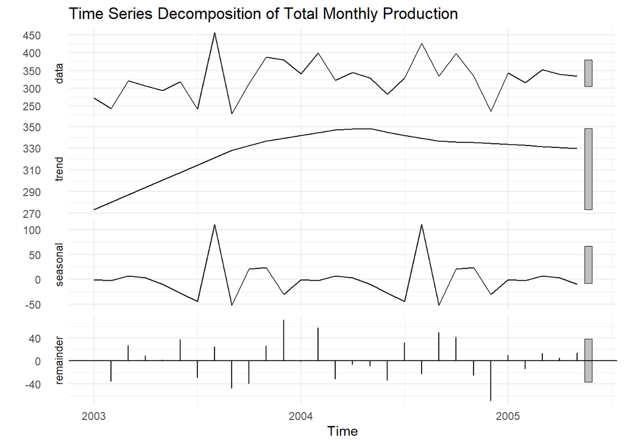

There is a clear indication of seasonality due to the perfectly repeating pattern in the seasonal portion of our time series decomposition, but we can’t yet tell if this repetition is due to just one or more product lines, so we will need to break it down into those categories.

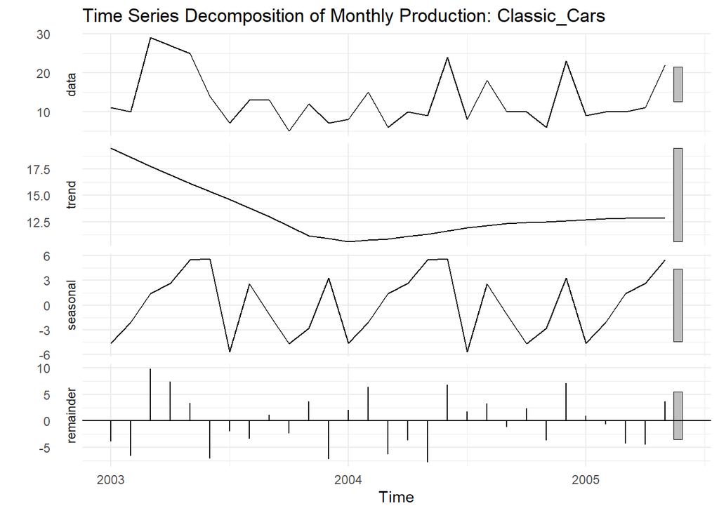

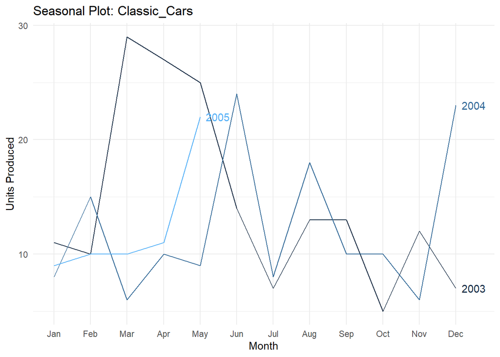

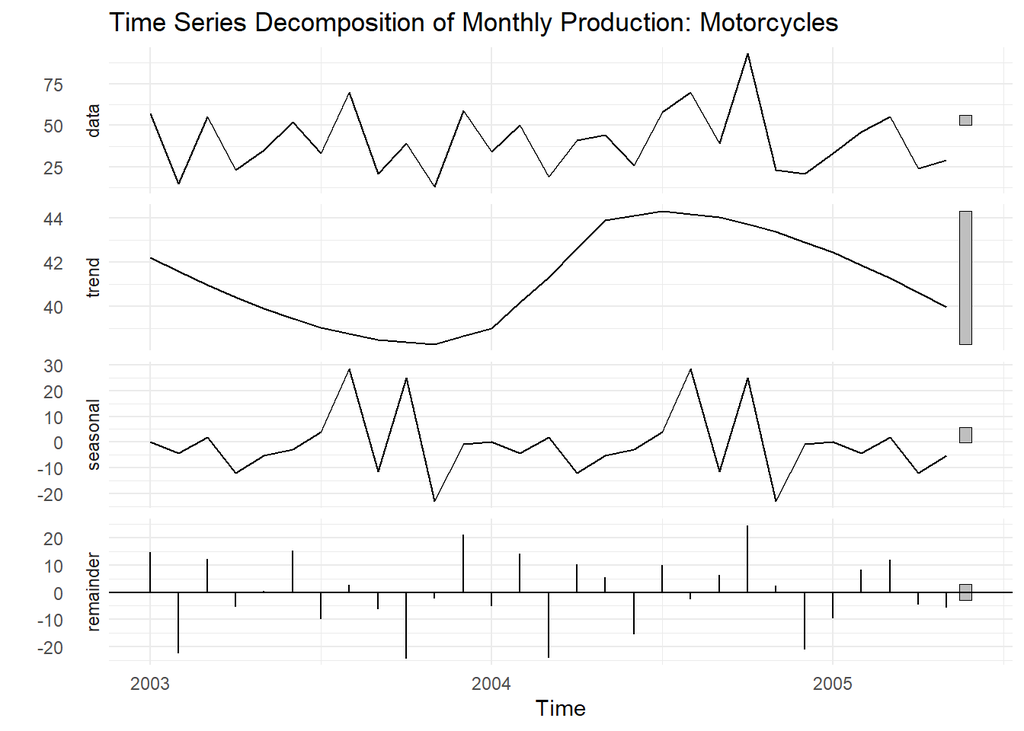

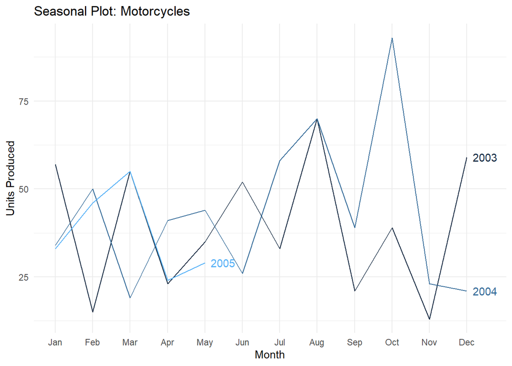

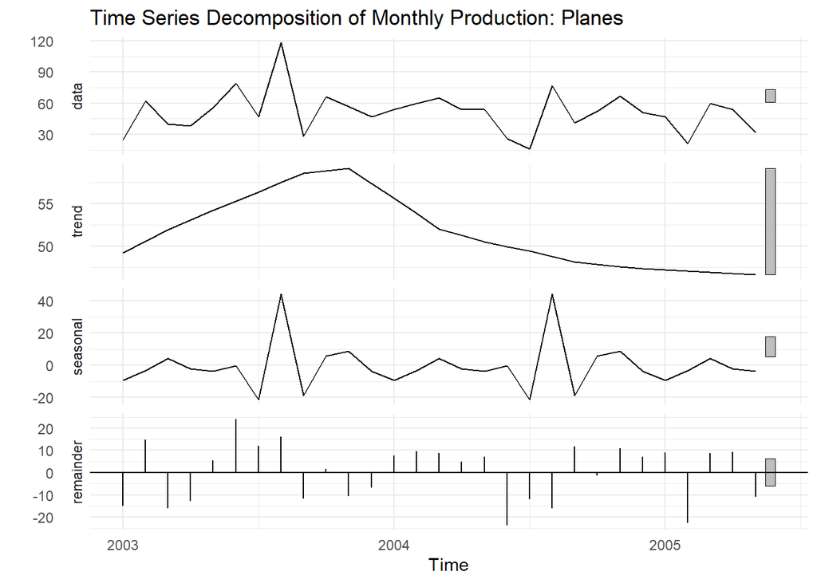

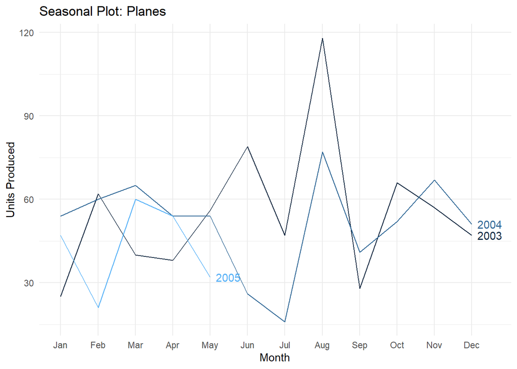

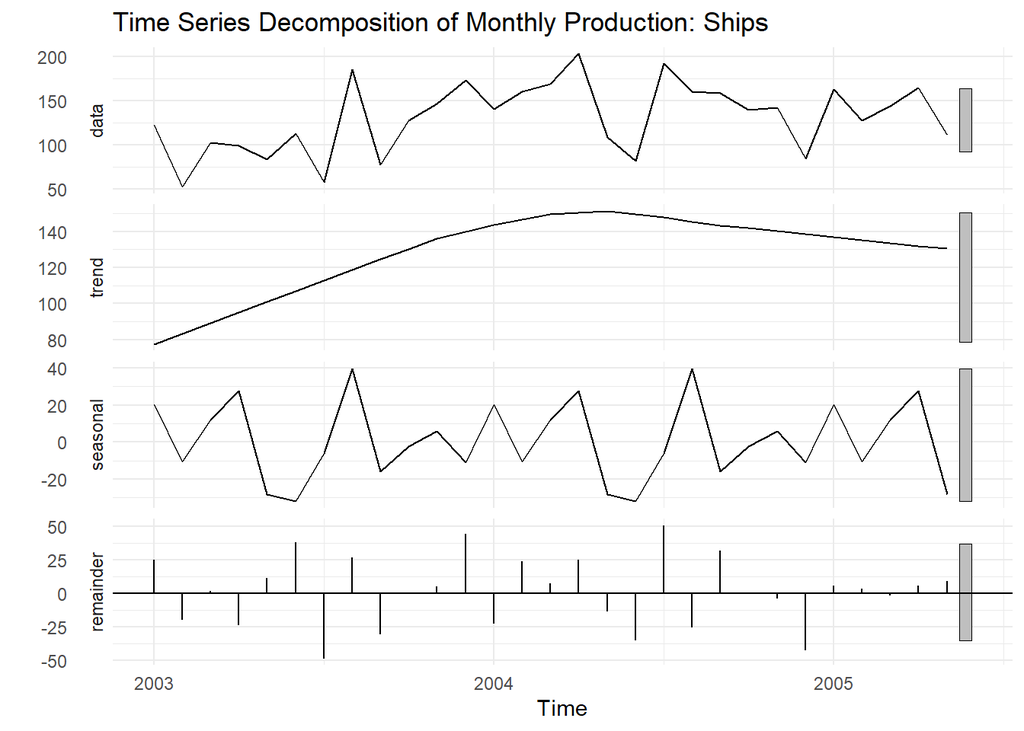

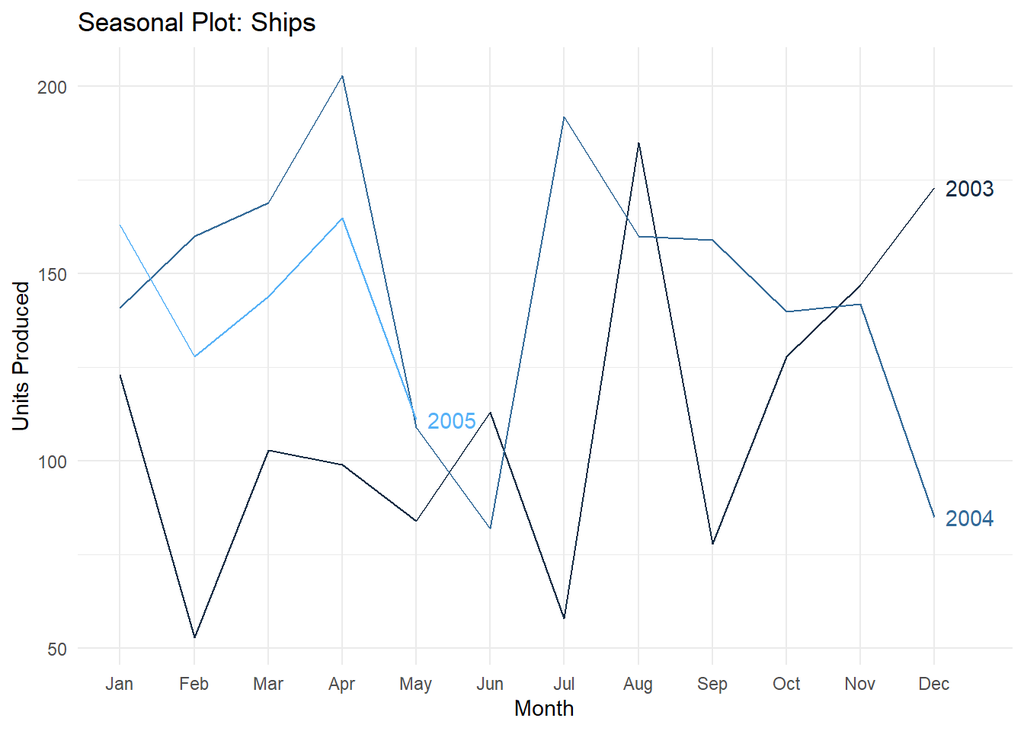

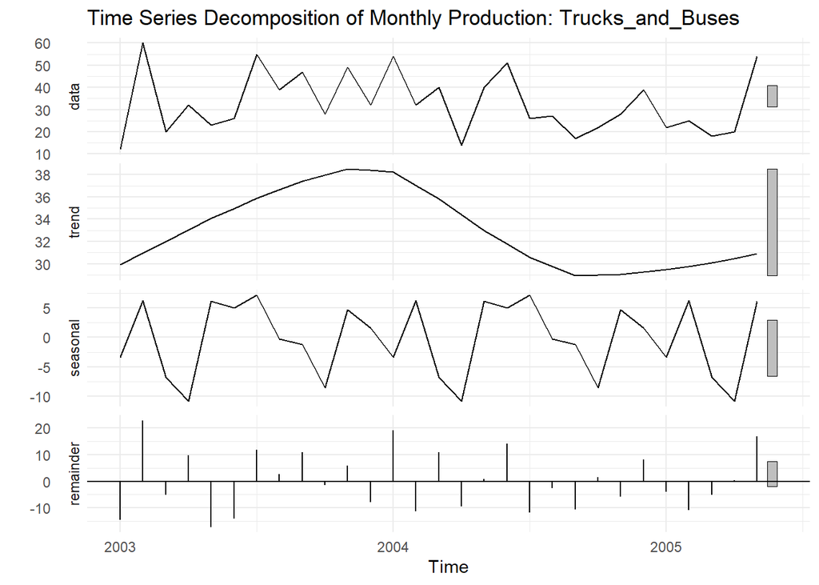

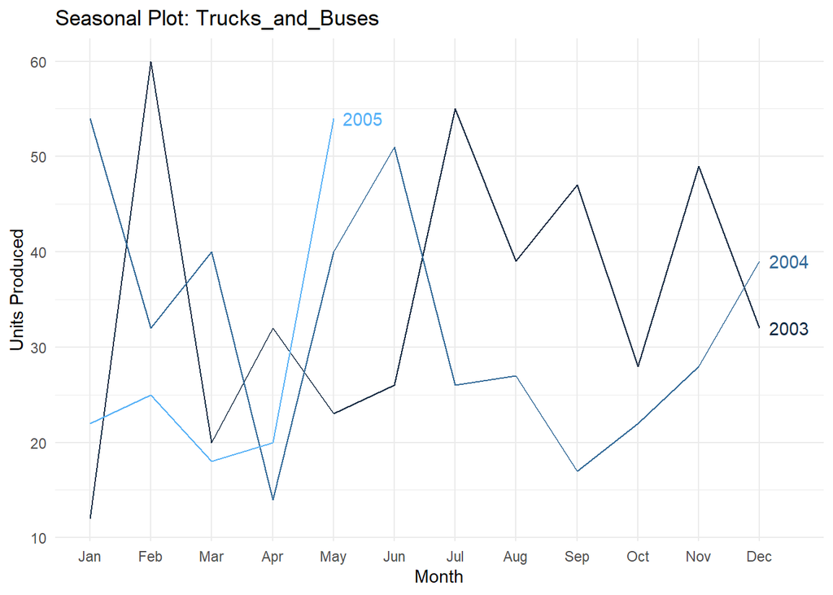

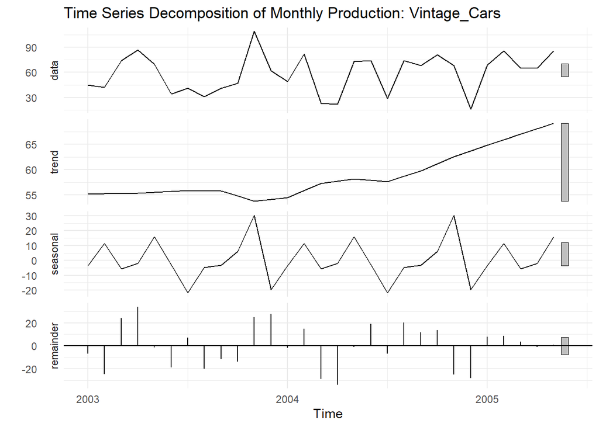

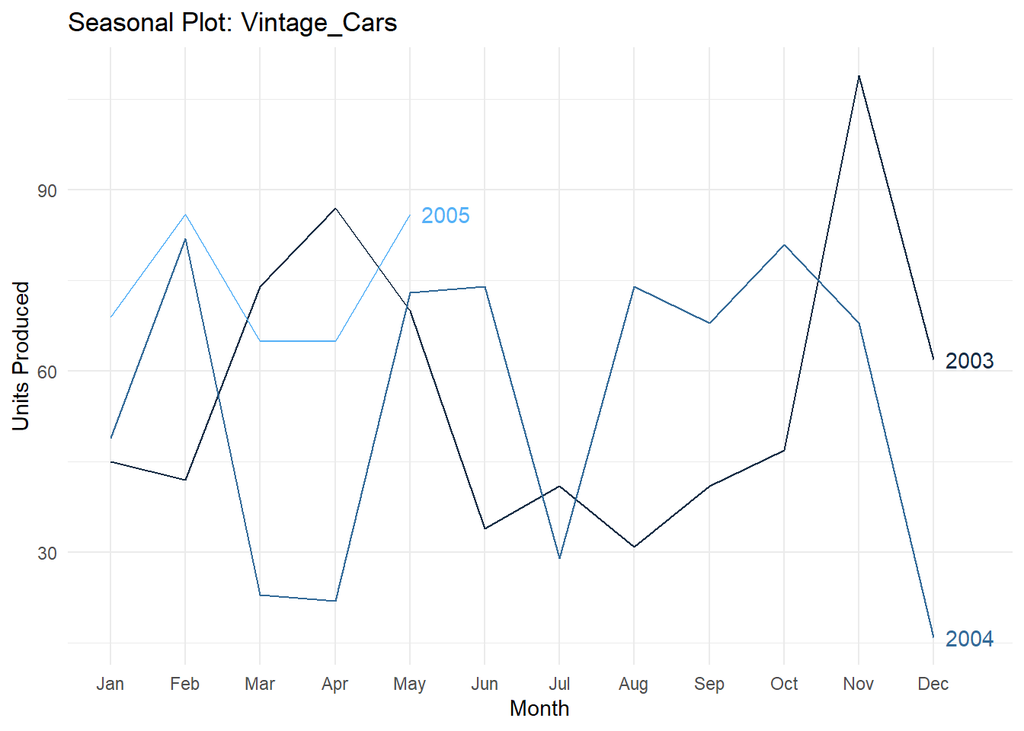

We can now see that all of the product lines show perfectly repeating seasonal patterns. There is also a general upward trend for the first year and four months, followed by a leveling off and slight decline. The individual product lines all have their own unique trends, however.

Lastly we will determine some basic monthly production data:

```
## Average Monthly Production:   328.1 units
```

```
## Peak Production Month:        2003-08 with 456 units
```

```
## Lowest Production Month:  2003-09 with 228 units
```

```
## Total Production by Product Line:
```

```
## # A tibble: 7 × 2
##   PRODUCTLINE      TOTAL_PRODUCED
##   <chr>                     <dbl>
## 1 Ships                      3797
## 2 Vintage_Cars               1713
## 3 Planes                     1494
## 4 Motorcycles                1177
## 5 Trucks_and_Buses            952
## 6 Classic_Cars                382
## 7 Trains                        0
```

## *Forecasting Production*

As a note, our production data doesn’t contain data regarding train production. Therefore, we will not be forecasting or analyzing trains for this section.

We have the accumulated data of our monthly productions. Based on our production history we would like to anticipate what our future production will look like. Bea will conduct an observation on our current production for trends or seasonality. This analysis will be conducted via STL decomposition to visualize trend lines and seasonality, and ploting our production timeline.

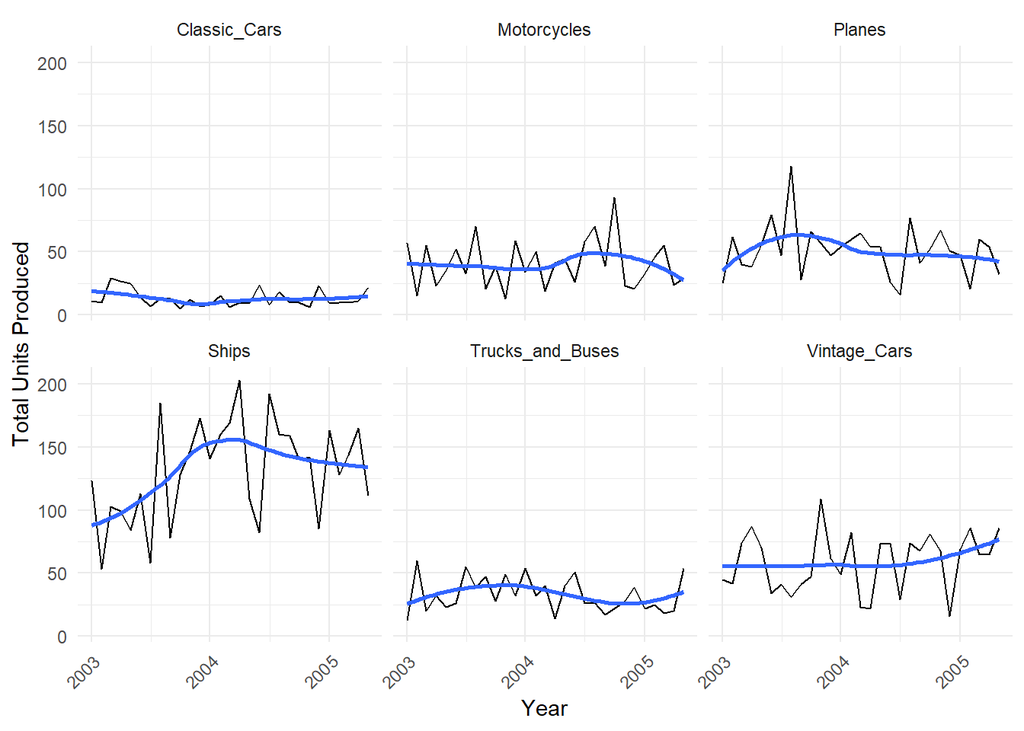

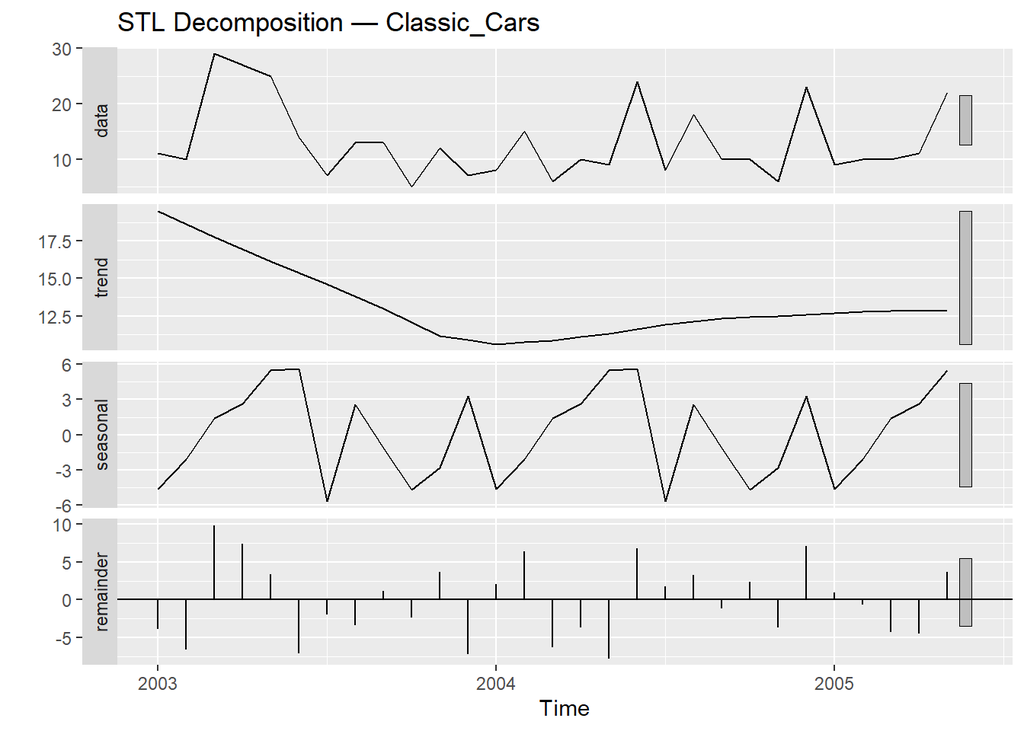

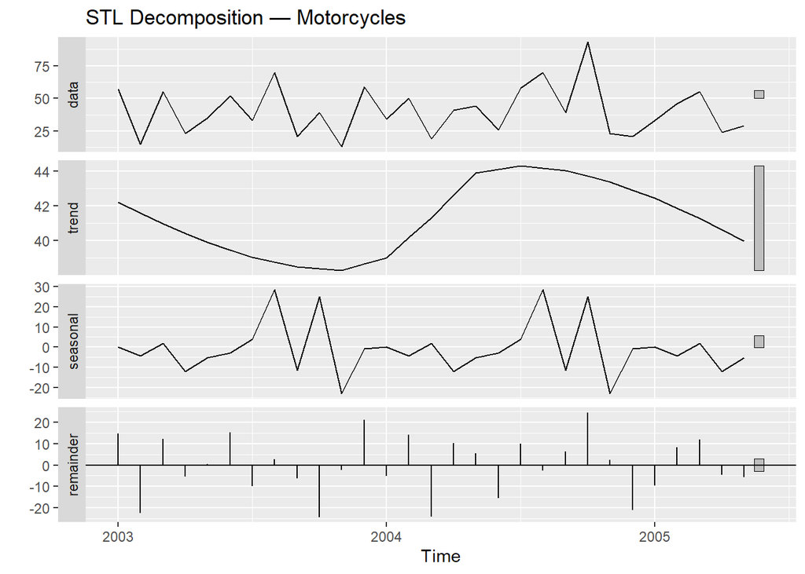

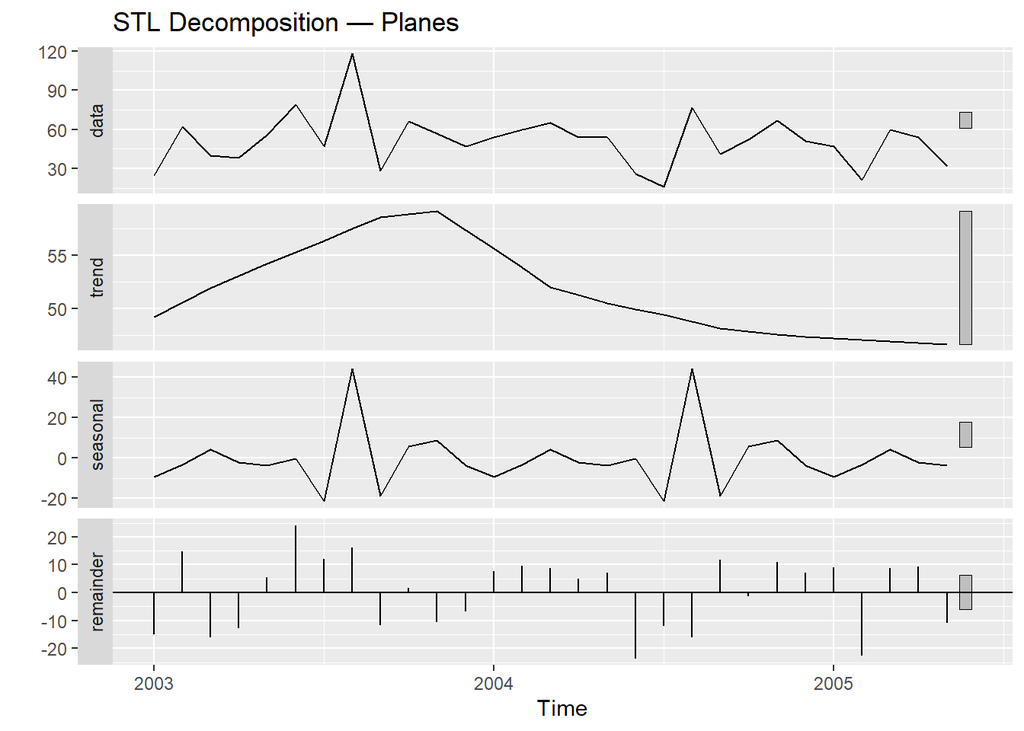

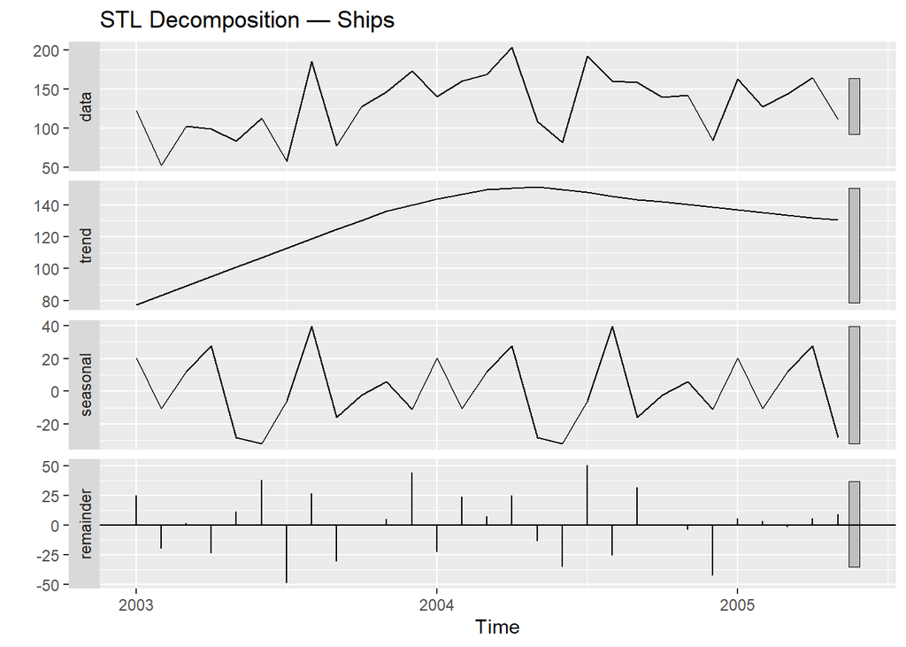

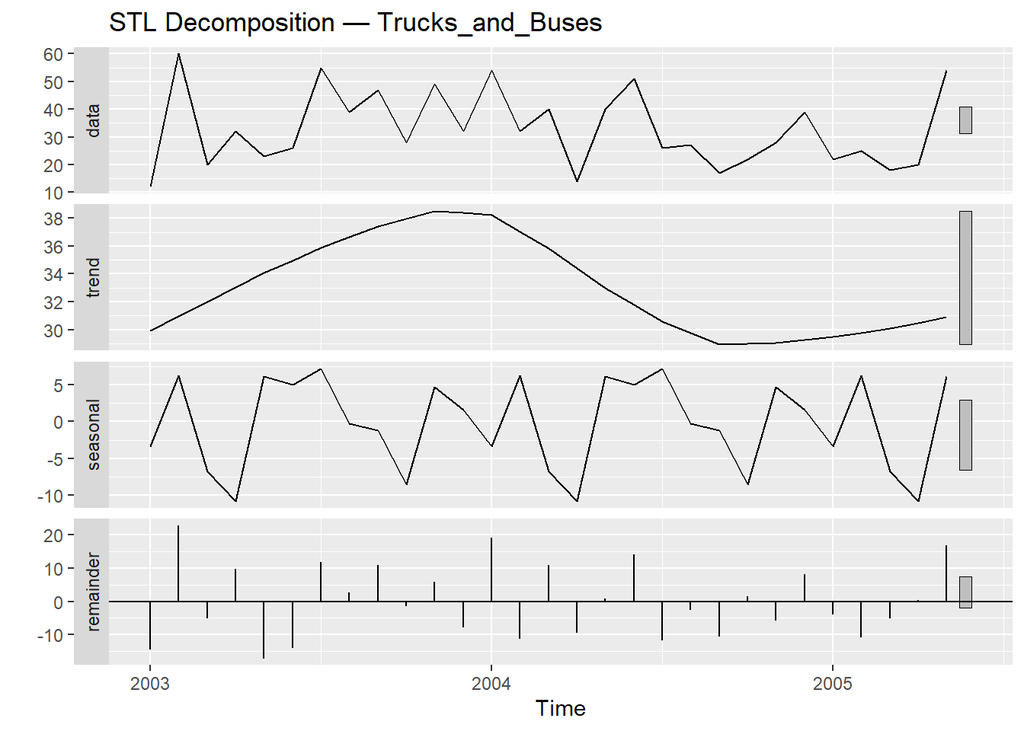

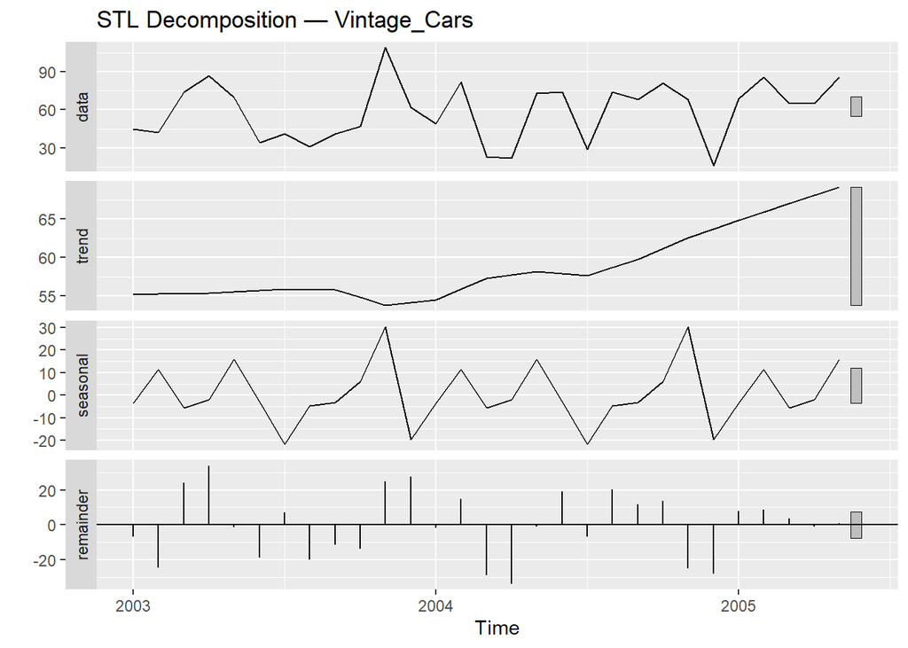

We will run an additional accuracy test between ARIMA, STL, ETS and Linear Regression to determine which forecasting would best suit our production lines.

```
##
## === Classic_Cars ===
##                   ME RMSE  MAE    MPE  MAPE MASE ACF1
## ETS_Auto           0 6.71 5.41 -24.74 47.22 0.69 0.15
## ARIMA              0 6.71 5.41 -24.73 47.21 0.69 0.15
## Linear_Regression  0 5.34 4.27 -15.22 37.04 0.54 0.11
## STL                0 5.46 4.23 -16.06 36.28 0.54 0.18
##
## === Motorcycles ===
##                     ME  RMSE   MAE    MPE  MAPE MASE  ACF1
## ETS_Auto          0.00 18.71 15.34 -25.73 49.47 0.71 -0.30
## ARIMA             0.15 17.79 14.12 -22.20 44.30 0.66  0.02
## Linear_Regression 0.00 13.50 11.50 -13.85 35.46 0.54 -0.23
## STL               0.00 13.39 11.40 -14.03 35.57 0.53 -0.21
##
## === Planes ===
##                      ME  RMSE   MAE    MPE  MAPE MASE  ACF1
## ETS_Auto          -0.01 20.13 14.53 -19.47 38.23 0.79 -0.24
## ARIMA              0.00 20.13 14.53 -19.46 38.22 0.79 -0.24
## Linear_Regression  0.00 13.23 11.72 -10.18 29.52 0.64  0.08
## STL                0.00 13.41 11.17 -10.59 28.43 0.61  0.16
##
## === Ships ===
##                     ME  RMSE   MAE   MPE  MAPE MASE  ACF1
## ETS_Auto          6.00 38.67 31.54 -4.88 27.67 0.66 -0.20
## ARIMA             5.48 38.71 31.29 -5.01 27.55 0.65 -0.21
## Linear_Regression 0.00 29.89 23.84 -7.12 21.72 0.50 -0.05
## STL               5.20 30.87 25.30 -1.57 22.09 0.53 -0.32
##
## === Trucks_and_Buses ===
##                      ME  RMSE   MAE    MPE  MAPE MASE  ACF1
## ETS_Auto           0.00 13.46 11.51 -19.68 42.45 0.58 -0.16
## ARIMA              0.00 13.46 11.51 -19.67 42.45 0.58 -0.16
## Linear_Regression  0.00 11.73  9.94 -14.51 35.28 0.50 -0.25
## STL               -0.01 11.75 10.29 -14.74 36.40 0.52 -0.18
##
## === Vintage_Cars ===
##                     ME  RMSE   MAE    MPE  MAPE MASE ACF1
## ETS_Auto          0.01 22.96 19.92 -24.62 49.07 0.64 0.07
## ARIMA             0.00 22.96 19.92 -24.63 49.08 0.64 0.07
## Linear_Regression 0.00 18.14 15.26 -16.34 36.74 0.49 0.16
## STL               0.00 18.38 16.51 -16.53 38.42 0.53 0.19
##
## === Trains ===
##                   ME RMSE MAE MPE MAPE MASE ACF1
## ETS_Auto           0    0   0 NaN  NaN  NaN  NaN
## ARIMA              0    0   0 NaN  NaN  NaN  NaN
## Linear_Regression  0    0   0 NaN  NaN  NaN  NaN
## STL                0    0   0 NaN  NaN  NaN  NaN
```

Due to the noise and lack of linearity within our production data ARIMA and ETS struggle to find auto correlations within the data, making their forecasting less reliable. Our accuracy charts indicate that Linear Regression would be the best forecasting model to use. However, Linear regression is best used for stable models with consitant rates over time. Past observations of our charts indicate there is little stability and linearity between our product lines except for Ships. Additional behind the scenes tests had also been conducted, and the forecasts of Linear Regression data projected negative values, enforcing the unreliability to use said model. Therefore, the second best option to use is an STL model to forecast our future productions.

```r
forecast_production <- function(product_line) {
  submodel <- Final_SalesXProduction_Productline %>%
    filter(PRODUCTLINE == product_line) %>%
    arrange(Month) %>%
    # Fill in missing order points with 0's
    tidyr::complete(
      Month = seq.Date(min(Month), max(Month), by = "month"),
      fill = list(TOTAL_UNITS_PRODUCED = 0)
    )

  ts_submodel <- ts(submodel$TOTAL_UNITS_PRODUCED,
                 start = c(year(min(submodel$Month)),
                           month(min(submodel$Month))),
                 frequency = 12)
  # Calculate Time series ranges
  last_date <- max(submodel$Month)
  target_end <- as.Date("2005-12-31")
  h <- interval(last_date, target_end) %/% months(1)

  # Use different series depending num months in dataset

  stl_model <- stl(ts_submodel, s.window = "periodic")
  ts_forecast <- forecast(stl_model, h=h)

  # Add a floor of 0 to reduce negative forecasting
  ts_forecast$lower[ts_forecast$lower < 0] <- 0

  # Display forecasting data
  cat("\n===", product_line, "===\n")
  print(ts_forecast)

  #plot the forecast
  autoplot(ts_forecast) +
    ggtitle(paste(product_line, "Orders Forecast"))

}

#Run all forecasts
product_lines <- unique(Final_SalesXProduction_Productline$PRODUCTLINE)
product_lines <- product_lines[product_lines != "Trains"]
#Map the products to the function
results <- map(product_lines, forecast_production)
```

```
##
## === Classic_Cars ===
##          Point Forecast       Lo 80    Hi 80     Lo 95    Hi 95
## Jun 2005      18.727312 11.36928971 26.08533 7.4741881 29.98044
## Jul 2005       7.389379  0.03135701 14.74740 0.0000000 18.64250
## Aug 2005      15.665083  8.30706109 23.02311 4.4119595 26.91821
## Sep 2005      11.940787  4.58276518 19.29881 0.6876635 23.19391
## Oct 2005       8.354173  0.99615034 15.71219 0.0000000 19.60730
## Nov 2005      10.267558  2.90953551 17.62558 0.0000000 21.52068
## Dec 2005      16.370633  9.01261055 23.72866 5.1175088 27.62376
##
## === Motorcycles ===
##          Point Forecast      Lo 80    Hi 80    Lo 95    Hi 95
## Jun 2005       38.49233 20.4858042 56.49885 10.95373 66.03092
## Jul 2005       45.09410 27.0875819 63.10063 17.55551 72.63270
## Aug 2005       69.79081 51.7842892 87.79733 42.25221 97.32941
## Sep 2005       29.98752 11.9809966 47.99404  2.44892 57.52612
## Oct 2005       66.18636 48.1798345 84.19288 38.64776 93.72496
## Nov 2005       18.38519  0.3786724 36.39172  0.00000 45.92379
## Dec 2005       40.43027 22.4237501 58.43679 12.89167 67.96887
##
## === Planes ===
##          Point Forecast    Lo 80     Hi 80     Lo 95     Hi 95
## Jun 2005       51.71419 33.58655  69.84182 23.990361  79.43801
## Jul 2005       30.55549 12.42785  48.68312  2.831661  58.27931
## Aug 2005       96.33688 78.20925 114.46452 68.613057 124.06071
## Sep 2005       33.11828 14.99064  51.24591  5.394453  60.84210
## Oct 2005       57.60297 39.47533  75.73060 29.879142  85.32679
## Nov 2005       60.58766 42.46002  78.71529 32.863831  88.31148
## Dec 2005       48.46225 30.33462  66.58989 20.738428  76.18608
##
## === Ships ===
##          Point Forecast     Lo 80    Hi 80     Lo 95    Hi 95
## Jun 2005       104.7595  63.34938 146.1696  41.42818 168.0908
## Jul 2005       130.6703  87.76441 173.5762  65.05138 196.2893
## Aug 2005       176.5177 132.16643 220.8690 108.68827 244.3472
## Sep 2005       120.8651  75.11409 166.6161  50.89496 190.8352
## Oct 2005       134.3165  87.20732 181.4257  62.26923 206.3638
## Nov 2005       142.7679  94.33862 191.1971  68.70172 216.8340
## Dec 2005       125.9499  76.23557 175.6642  49.91841 201.9813
##
## === Trucks_and_Buses ===
##          Point Forecast    Lo 80    Hi 80      Lo 95    Hi 95
## Jun 2005       38.15820 22.33248 53.98393 13.9548449 62.36156
## Jul 2005       40.33526 24.50953 56.16098 16.1319008 64.53862
## Aug 2005       32.88120 17.05548 48.70693  8.6778431 57.08456
## Sep 2005       31.92714 16.10142 47.75287  7.7237854 56.13050
## Oct 2005       24.62479  8.79906 40.45051  0.4214276 48.82814
## Nov 2005       37.82243 21.99670 53.64815 13.6190698 62.02579
## Dec 2005       34.76301 18.93728 50.58873 10.5596477 58.96636
##
## === Vintage_Cars ===
##          Point Forecast    Lo 80     Hi 80     Lo 95     Hi 95
## Jun 2005       55.73092 31.05884  80.40301 17.998222  93.46362
## Jul 2005       36.74032 12.06823  61.41240  0.000000  74.47301
## Aug 2005       53.72676 29.05468  78.39885 15.994063  91.45946
## Sep 2005       55.21321 30.54112  79.88530 17.480510  92.94591
## Oct 2005       64.55448 39.88239  89.22657 26.821781 102.28718
## Nov 2005       88.89575 64.22367 113.56784 51.163052 126.62845
## Dec 2005       38.74535 14.07326  63.41744  1.012648  76.47805
```

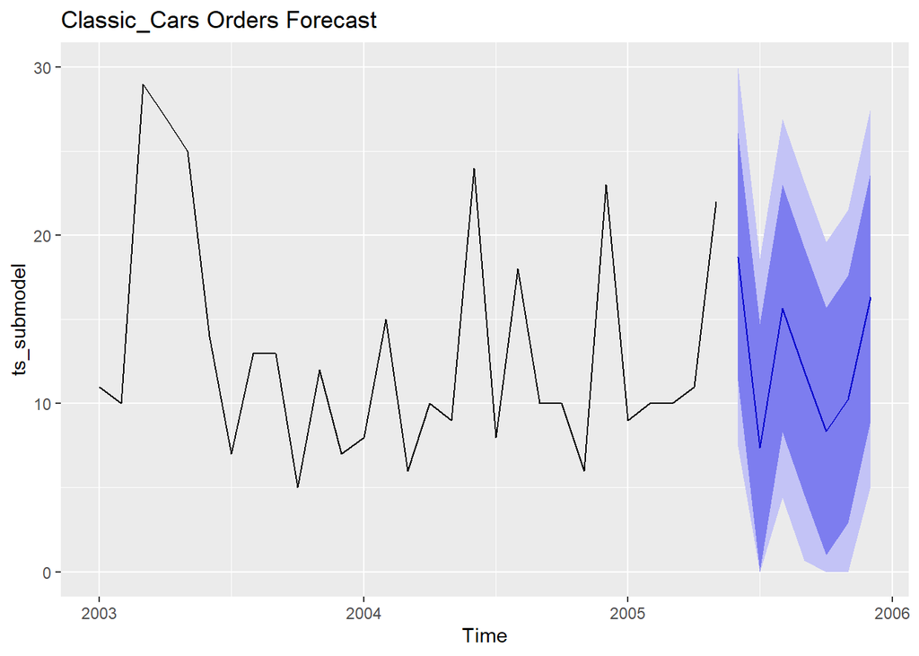

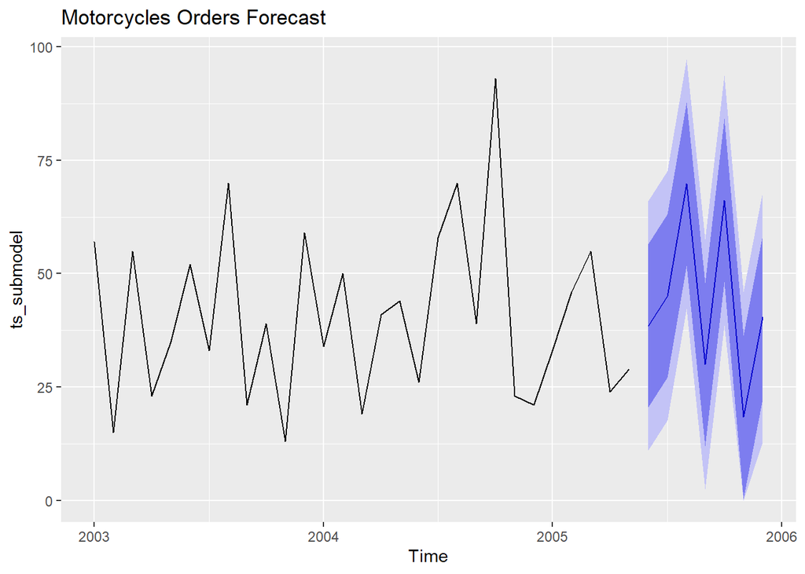

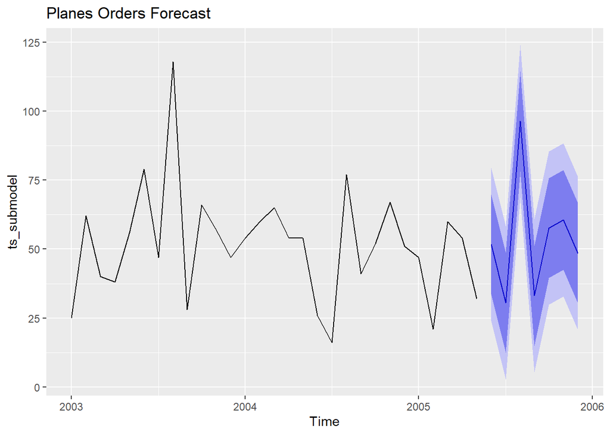

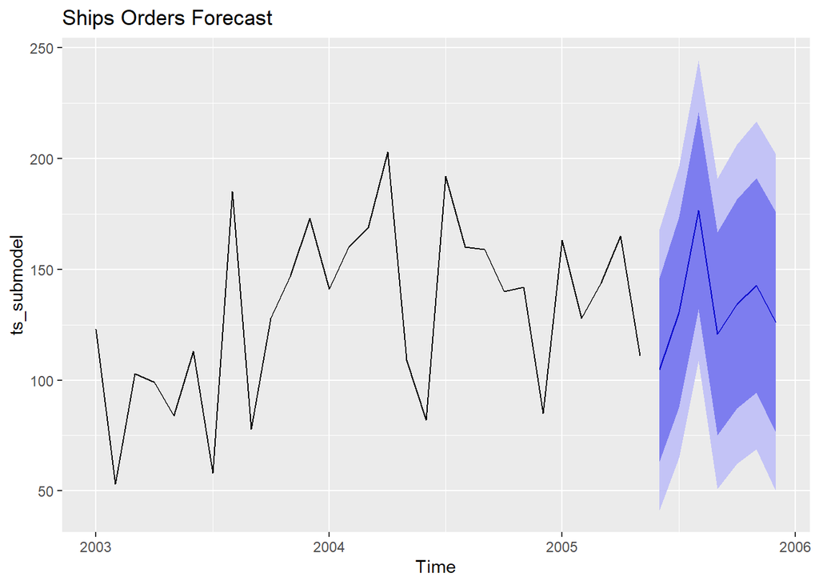

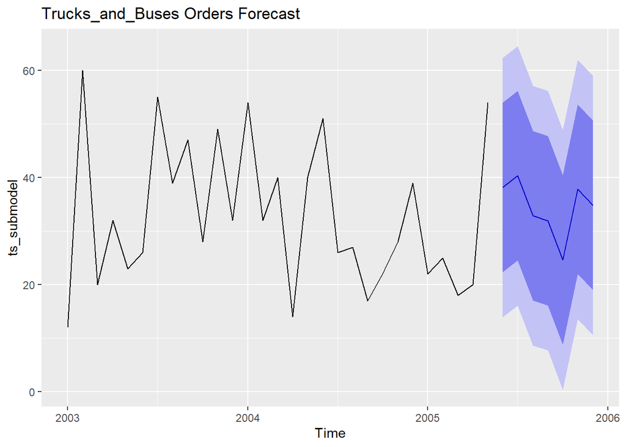

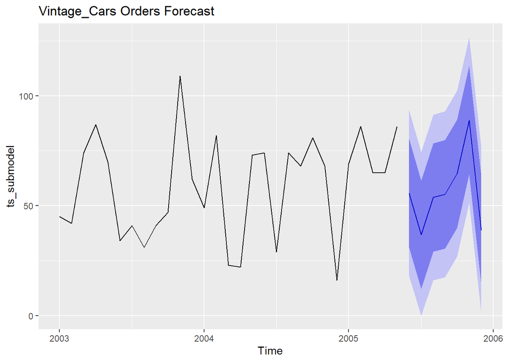

```r
results
```

## *Cost and Profit Analysis*

##### Analysis by Kainen

This section examines the historical profitability of each product line using the cleaned and joined production and sales data constructed in the Data Refinement section. Profit is defined as total sales revenue minus the average production cost including the factory base cost:

**Profit = Total Sales - Average Production Cost (with Factory Base)**

This definition accounts for both the variable cost of producing each unit and the fixed operational base cost attributed to the factory, as isolated by the master regression model.

### Historical Profit by Product Line

The table below summarizes the total historical profit generated by each product line across all available months (January 2003 – May 2005).

```r
fmt_dollar <- function(x) paste0("$", format(round(x), big.mark = ","))

historical_profit <- Final_SalesXProduction_Productline %>%
  filter(!is.na(TOTAL_SALES), !is.na(AVG_PRODUCTION_COST_W_BASE)) %>%
  mutate(actual_profit = TOTAL_SALES - AVG_PRODUCTION_COST_W_BASE) %>%
  group_by(PRODUCTLINE) %>%
  summarise(
    months_observed    = n(),
    total_profit       = sum(actual_profit, na.rm = TRUE),
    avg_monthly_profit = mean(actual_profit, na.rm = TRUE),
    .groups = "drop"
  ) %>%
  arrange(desc(total_profit))

historical_profit$total_profit       <- fmt_dollar(historical_profit$total_profit)
historical_profit$avg_monthly_profit <- fmt_dollar(historical_profit$avg_monthly_profit)
colnames(historical_profit) <- c("Product Line", "Months Observed",
                                  "Total Historical Profit", "Avg Monthly Profit")
print(historical_profit, row.names = FALSE)
```

```
## # A tibble: 6 × 4
##   `Product Line`   `Months Observed` Total Historical Pro…¹ `Avg Monthly Profit`
##   <chr>                        <int> <chr>                  <chr>
## 1 Classic_Cars                    29 $3,874,639             $133,608
## 2 Vintage_Cars                    29 $1,773,084             $ 61,141
## 3 Motorcycles                     27 $1,076,784             $ 39,881
## 4 Trucks_and_Buses                26 $1,043,004             $ 40,116
## 5 Planes                          23 $  859,960             $ 37,390
## 6 Ships                           23 $  655,562             $ 28,503
## # ℹ abbreviated name: ¹`Total Historical Profit`
```

#### Average Profit Per Unit by Product Line

To project future profitability from forecasted production volumes, we need to know how much profit each unit of production generates on average. This is calculated by dividing the monthly actual profit by the number of units produced in that month, then averaging across all months where both figures are available.

```r
profit_per_unit <- Final_SalesXProduction_Productline %>%
  filter(!is.na(TOTAL_SALES),
         !is.na(AVG_PRODUCTION_COST_W_BASE),
         !is.na(TOTAL_UNITS_PRODUCED),
         TOTAL_UNITS_PRODUCED > 0) %>%
  mutate(
    actual_profit = TOTAL_SALES - AVG_PRODUCTION_COST_W_BASE,
    ppu           = actual_profit / TOTAL_UNITS_PRODUCED
  ) %>%
  group_by(PRODUCTLINE) %>%
  summarise(
    avg_profit_per_unit = mean(ppu, na.rm = TRUE),
    n_months            = n(),
    .groups = "drop"
  ) %>%
  arrange(desc(avg_profit_per_unit))

ppu_table <- profit_per_unit
ppu_table$avg_profit_per_unit <- fmt_dollar(ppu_table$avg_profit_per_unit)
colnames(ppu_table) <- c("Product Line", "Avg Profit Per Unit", "Months of Data")
print(ppu_table, row.names = FALSE)
```

```
## # A tibble: 6 × 3
##   `Product Line`   `Avg Profit Per Unit` `Months of Data`
##   <chr>            <chr>                            <int>
## 1 Classic_Cars     $13,643                             29
## 2 Motorcycles      $ 1,376                             27
## 3 Trucks_and_Buses $ 1,350                             26
## 4 Vintage_Cars     $ 1,209                             29
## 5 Planes           $   810                             23
## 6 Ships            $   231                             23
```

#### Historical Profit Visualizations

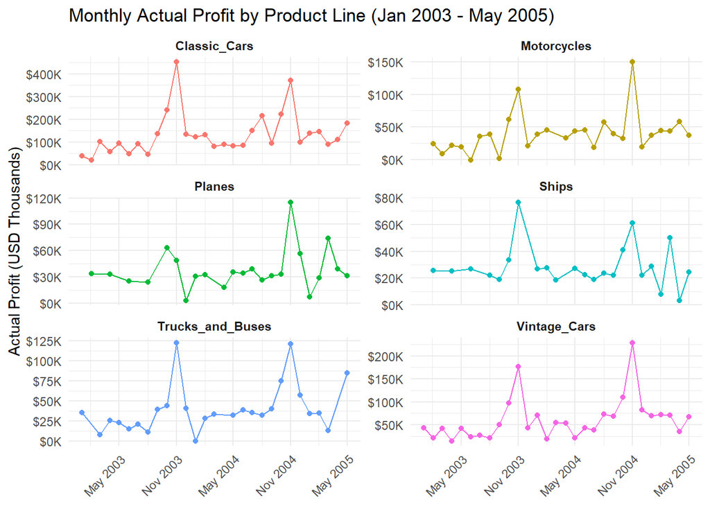

```r
plot_data <- Final_SalesXProduction_Productline %>%
  filter(!is.na(ACTUAL_TOTAL_PROFIT), !is.na(Month))

# Monthly profit over time by product line
ggplot(plot_data, aes(x = Month, y = ACTUAL_TOTAL_PROFIT / 1e3, color = PRODUCTLINE)) +
  geom_line() +
  geom_point(size = 1.5) +
  facet_wrap(~ PRODUCTLINE, scales = "free_y", ncol = 2) +
  scale_y_continuous(labels = scales::label_dollar(suffix = "K")) +
  scale_x_date(date_breaks = "6 months", date_labels = "%b %Y") +
  labs(title = "Monthly Actual Profit by Product Line (Jan 2003 - May 2005)",
       x     = NULL,
       y     = "Actual Profit (USD Thousands)") +
  theme_minimal() +
  theme(axis.text.x = element_text(angle = 45, hjust = 1),
        legend.position = "none",
        strip.text = element_text(face = "bold"))
```

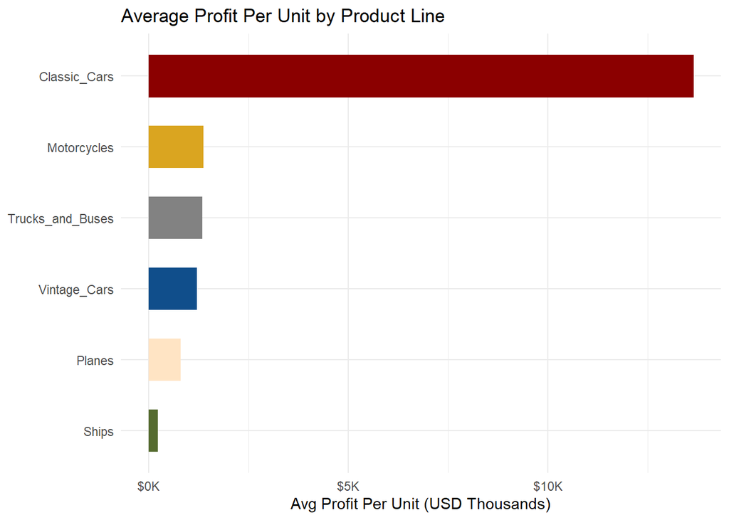

```r
profit_per_unit$PRODUCTLINE <- reorder(profit_per_unit$PRODUCTLINE,
                                        profit_per_unit$avg_profit_per_unit)

ggplot(profit_per_unit,
       aes(x = avg_profit_per_unit / 1e3, y = PRODUCTLINE, fill = PRODUCTLINE)) +
  geom_col(width = 0.6, show.legend = FALSE) +
  scale_fill_manual(values = palette) +
  scale_x_continuous(labels = scales::label_dollar(suffix = "K")) +
  labs(title = "Average Profit Per Unit by Product Line",
       x     = "Avg Profit Per Unit (USD Thousands)",
       y     = NULL) +
  theme_minimal()
```